# Štatistické metódy vyhodnocovania experimentov

Tomáš Bacigál

16.3.2021

```r
`%>%` <- magrittr::`%>%`  # pipe operator
```

# 4 Testovanie štatistických hypotéz

Technicky, testovanie štat.hypotéz a konštrukcia intervalov spoľahlivosti používa rovnaký postup, rozdiel je len v závere. Pri testovaní nás zaujíma odpoveď na otázku: dá sa na základe dostupných pozorovaní zamietnuť (nulová) hypotéza?

## 4.1 Jedno-výberové testy o parametroch rozdelenia

### 4.1.1 Podiel

**Príklad**.

Vráťme sa k prieskumu obľúbenosti značky ABC medzi kupujúcimi, kde sa v ankete 42 ľudí zo 100 vyjadrilo, že má rado značku ABC. Môžeme tvrdiť, že práve polovica všetkých spotrebiteľov má rada ABC?  
Riešenie:  
Najprv treba formulovať nulovú hypotézu H0: Parameter obľúbenosti výrobku pre základný súbor je $p_0=50\%$. Alternatívna H1: $p_0\neq 0.5$ v prípade obojstranného testu.  
Ak platí H0, testovacia štatistika $TS=\frac{p-p_0}{\sigma}$ má asymptoticky N(0,1) rozdelenie.

```r
p0 <- 0.5  # parameter alt.rozdelenia za predpokladu platnosti H0
n <- 100  # sample size
alpha <- 0.05  # hladina významnosti
TS <- (42/100-p0) / sqrt(p0*(1-p0)/n)  # testovacia štatistika
c(test_statistika = TS,
  krit_hodnota = qnorm(c(alpha/2, 1-alpha/2)),  # kvantil norm.rozd.
  p_hodnota = 2*pnorm(TS)
  )
```

```
## test_statistika   krit_hodnota1   krit_hodnota2       p_hodnota
##      -1.6000000      -1.9599640       1.9599640       0.1095986
```

Testovacia štatistika padla medzi kritické hodnoty, preto na 5% hladine významnosti nemôžeme zamietnuť hypotézu o tom, že polovica ľudí má rada značku ABC. To je vidieť aj z porovnania p-hodnoty s hladinou významnosti. P-hodnota sa vypočíta ako plocha pod hustotou rozdelenia testovacej štatistiky (tu normálneho) “za” bodovým odhadom testovacej štatistiky (v zmysle “smerom ku chvostu” rozdelenia). V prípade obojstranného testu je p-hodnota dvojnásobok tej plochy.

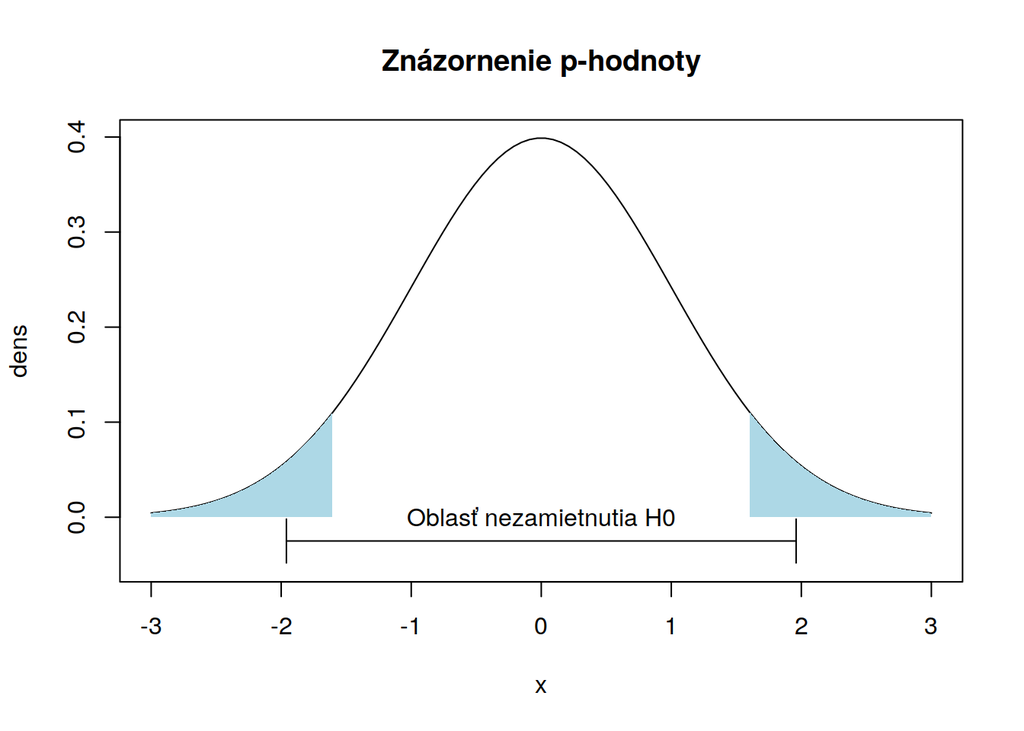

```r
x <- seq(-3, 3, length.out = 100)
dens <- dnorm(x)
ind <- list(l = which(x<=-abs(TS)), r = which(x>=abs(TS)))
plot(x, dens, type = "l", ylim = c(-0.05, 0.4), main = "Znázornenie p-hodnoty")
polygon(x = c(x[1], x[ind$l], x[tail(ind$l,1)]), y = c(0, dens[ind$l], 0),
        col="lightblue", border = NA)
polygon(x = c(x[ind$r[1]], x[ind$r], tail(x,1)), y = c(0, dens[ind$r], 0),
        col="lightblue", border = NA)
arrows(x0 = qnorm(alpha/2), y0=-0.025, x1 = qnorm(1 - alpha/2), y1 = -0.025,
       angle = 90, code = 3, length = 0.15)
text(x = 0, y = -0.025, labels = "Oblasť nezamietnutia H0", pos = 3)
```

Použitie alternatívnych testov:

```r
binom.test(42, 100, p=0.5)
```

```
##
##  Exact binomial test
##
## data:  42 and 100
## number of successes = 42, number of trials = 100, p-value = 0.1332
## alternative hypothesis: true probability of success is not equal to 0.5
## 95 percent confidence interval:
##  0.3219855 0.5228808
## sample estimates:
## probability of success
##                   0.42
```

```r
prop.test(42, 100, p=0.5)
```

```
##
##  1-sample proportions test with continuity correction
##
## data:  42 out of 100, null probability 0.5
## X-squared = 2.25, df = 1, p-value = 0.1336
## alternative hypothesis: true p is not equal to 0.5
## 95 percent confidence interval:
##  0.3233236 0.5228954
## sample estimates:
##    p
## 0.42
```

### 4.1.2 Stredná hodnota

**Príklad**

Výrobca modelu auta deklaruje dojazd 25mpg (míľ na galón paliva). Z prieskumnej vzorky 10 vlastníkov áut daného modelu bol zistený priemerný dojazd 23mpg a štandardná odchýlka 2.5mpg. Dá sa výrobcovi veriť?  
Riešenie:

```r
xmean <- 23; xsd <- 2.5
( TS <- (xmean-25)/(xsd/sqrt(10)) )
```

```
## [1] -2.529822
```

```r
( pt(TS, df=10-1) )  # p-hodnota < 0.05
```

```
## [1] 0.01612239
```

H0 o rovnosti skutočného a deklarovaného dojazdu musíme zamietnuť.  
Situácia tentokrát pomocou ggplot:

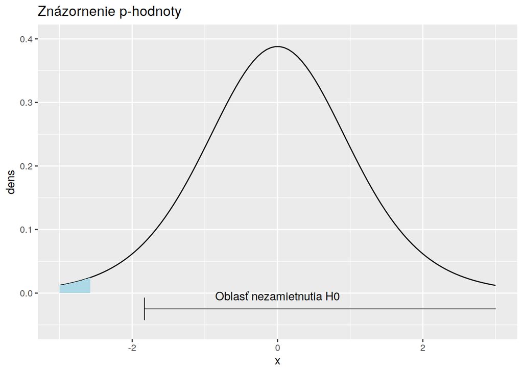

```r
library(ggplot2)
data.frame(x = seq(-3, 3, length.out = 100)) %>%  # mriežka x-ových hodnôt
  dplyr::mutate(dens = dt(x, df=10-1)) %>%   # pridá y-ove
  ggplot(mapping = aes(x = x, y = dens)) +
  geom_line() +
  geom_ribbon(mapping = aes(x = ifelse(x < TS, x, NA), ymin = 0, ymax = dens),
              fill = "lightblue") +  # pridá plochu = p-value
  coord_cartesian(ylim=c(-0.05,0.4)) +  # trochu miesta pod grafom
  geom_segment(x = qt(0.05, df=10-1), y = -0.025, xend = max(x), yend = -0.025,
               arrow = arrow(angle=90, length = unit(0.15, "inches"), ends = "first"),
               size = 0.1) +  # úsečka s jedným ukončením
  annotate("text", label = "Oblasť nezamietnutia H0", x = 0, y = -0.025, vjust=-1) +
  ggtitle("Znázornenie p-hodnoty")
```

### 4.1.3 Medián

**Príklad**

Sú k dispozícii dĺžky volania jedného užívateľa (v minútach).

```r
x <- c(12.8, 3.5, 2.9, 9.4, 8.7, .7, .2, 2.8, 1.9, 2.8, 3.1, 15.8)
```

Môžme použiť t-test? Testujte hypotézu, ze užívateľ nevolá viac ako 5 min.  
Riešenie:

```r
stem(x)  # stonkovo-listový graf indikuje veľmi nesymetrické rozdelenie
```

```
##
##   The decimal point is 1 digit(s) to the right of the |
##
##   0 | 01233334
##   0 | 99
##   1 | 3
##   1 | 6
```

```r
wilcox.test(x, mu=5, alt="greater")  # neparametrický test
```

```
##
##  Wilcoxon signed rank test with continuity correction
##
## data:  x
## V = 39, p-value = 0.5156
## alternative hypothesis: true location is greater than 5
```